# 10 Minutes to Dask

## 목차

- Dask DataFrame
- Dask Array
- Dask Bag
- Low-Level 인터페이스 : Dask Delayed
- 스케줄링 Client
- 진단 Dashboard

일반적으로 다음과 같이 Dask를 import 합니다. 작업 중인 데이터 유형(DataFrame, array, list)에 따라 이들 중 일부가 필요하지 않을 수도 있습니다.

```python
import numpy as np
import pandas as pd

import dask.dataframe as dd
import dask.array as da
import dask.bag as db
```

# Dask DataFrame

## Dask 객체 생성

먼저, Dask DataFrame을 활용해 Pandas DataFrame 유형의 데이터를 작업해보도록 하겠습니다.

```python
index = pd.date_range("2021-09-01", periods=2400, freq="1H")
df = pd.DataFrame({"a": np.arange(2400), "b": list("abcaddbe" * 300)}, index=index)
df
```

|  | a | b |
| --- | --- | --- |
| 2021-09-01 00:00:00 | 0 | a |
| 2021-09-01 01:00:00 | 1 | b |
| 2021-09-01 02:00:00 | 2 | c |
| 2021-09-01 03:00:00 | 3 | a |
| 2021-09-01 04:00:00 | 4 | d |
| ... | ... | ... |
| 2021-12-09 19:00:00 | 2395 | a |
| 2021-12-09 20:00:00 | 2396 | d |
| 2021-12-09 21:00:00 | 2397 | d |
| 2021-12-09 22:00:00 | 2398 | b |
| 2021-12-09 23:00:00 | 2399 | e |

2400 rows × 2 columns

```python
ddf = dd.from_pandas(df, npartitions=10)
ddf
```

**Dask DataFrame Structure:**

| npartitions=10 | a | b |
| --- | --- | --- |
| 2021-09-01 00:00:00 | int32 | string |
| 2021-09-11 00:00:00 | ... | ... |
| ... | ... | ... |
| 2021-11-30 00:00:00 | ... | ... |
| 2021-12-09 23:00:00 | ... | ... |

Dask Name: to_pyarrow_string, 2 graph layers

이제 2개의 열, 2400개의 행으로 구성된 Dask DataFrame이 있습니다. 이 Dask DataFrame은 2400개 행을 10개의 파티션(partition)으로 나누며, 따라서 각 파티션은 240개 행으로 구성되어 있습니다. 여기서 파티션은 데이터 조각을 나타냅니다.

다음은 Dask DataFrame의 몇 가지 주요 속성입니다.

```python
# 각 파티션이 포함하는 인덱스 값 확인
ddf.divisions
```

```
(Timestamp('2021-09-01 00:00:00'),
 Timestamp('2021-09-11 00:00:00'),
 Timestamp('2021-09-21 00:00:00'),
 Timestamp('2021-10-01 00:00:00'),
 Timestamp('2021-10-11 00:00:00'),
 Timestamp('2021-10-21 00:00:00'),
 Timestamp('2021-10-31 00:00:00'),
 Timestamp('2021-11-10 00:00:00'),
 Timestamp('2021-11-20 00:00:00'),
 Timestamp('2021-11-30 00:00:00'),
 Timestamp('2021-12-09 23:00:00'))
```

```python
# 특정 파티션에 액세스
ddf.partitions[1]
```

**Dask DataFrame Structure:**

| npartitions=1 | a | b |
| --- | --- | --- |
| 2021-09-11 | int32 | string |
| 2021-09-21 | ... | ... |

Dask Name: blocks, 3 graph layers

## 인덱싱 (Indexing)

Dask DataFrame의 인덱싱은 pandas DataFrame을 슬라이싱(slicing)하는 것과 유사합니다.

```python
ddf.b
```

```
Dask Series Structure:
npartitions=10
2021-09-01 00:00:00    string
2021-09-11 00:00:00       ...
                        ...
2021-11-30 00:00:00       ...
2021-12-09 23:00:00       ...
Name: b, dtype: string
Dask Name: getitem, 3 graph layers
```

```python
ddf["2021-10-01": "2021-10-09 5:00"]
```

**Dask DataFrame Structure:**

| npartitions=1 | a | b |
| --- | --- | --- |
| 2021-10-01 00:00:00.000000000 | int32 | string |
| 2021-10-09 05:00:59.999999999 | ... | ... |

Dask Name: loc, 3 graph layers

## 연산 (Computation)

연산 결과는 사용자가 요청할 때까지 계산되지 않으며, 대신에 연산 과정을 정리한 Dask 작업 그래프가 생성됩니다. 연산 결과를 얻고 싶다면 `compute`를 호출해야 합니다.

```python
ddf["2021-10-01": "2021-10-09 5:00"].compute()
```

|  | a | b |
| --- | --- | --- |
| 2021-10-01 00:00:00 | 720 | a |
| 2021-10-01 01:00:00 | 721 | b |
| 2021-10-01 02:00:00 | 722 | c |
| 2021-10-01 03:00:00 | 723 | a |
| 2021-10-01 04:00:00 | 724 | d |
| ... | ... | ... |
| 2021-10-09 01:00:00 | 913 | b |
| 2021-10-09 02:00:00 | 914 | c |
| 2021-10-09 03:00:00 | 915 | a |
| 2021-10-09 04:00:00 | 916 | d |
| 2021-10-09 05:00:00 | 917 | d |

198 rows × 2 columns

## 메서드 (Methods)

Dask DataFrame의 메서드는 기존 Pandas 메서드와 일치합니다. 메서드를 호출하여 작업 그래프(task graph)를 설정한 다음, `compute`를 호출하여 결과를 가져옵니다.

```python
ddf.a.mean()
```

```
dd.Scalar<series-..., dtype=float64>
```

```python
ddf.a.mean().compute()
```

```
1199.5
```

```python
ddf.b.unique()
```

```
Dask Series Structure:
npartitions=1
    string
       ...
Name: b, dtype: string
Dask Name: unique-agg, 5 graph layers
```

```python
ddf.b.unique().compute()
```

```
0    a
1    b
2    c
3    d
4    e
Name: b, dtype: string
```

Pandas처럼 여러 메서드를 함께 연결하여 사용할 수도 있습니다.

```python
result = ddf["2021-10-01": "2021-10-09 5:00"].a.cumsum() - 100
result
```

```
Dask Series Structure:
npartitions=1
2021-10-01 00:00:00.000000000    int32
2021-10-09 05:00:59.999999999      ...
Name: a, dtype: int32
Dask Name: sub, 8 graph layers
```

```python
result.compute()
```

```
2021-10-01 00:00:00       620
2021-10-01 01:00:00      1341
2021-10-01 02:00:00      2063
2021-10-01 03:00:00      2786
2021-10-01 04:00:00      3510
                        ...
2021-10-09 01:00:00    158301
2021-10-09 02:00:00    159215
2021-10-09 03:00:00    160130
2021-10-09 04:00:00    161046
2021-10-09 05:00:00    161963
Freq: H, Name: a, Length: 198, dtype: int32
```

## 작업 그래프 (Task Graph) 시각화

지금까지 연산 작업을 설정하고 `compute`를 호출했습니다. 추가적으로, `compute`를 호출하기 전에 작업 그래프(task graph)를 검사하여 연산 과정을 파악하고 검토할 수 있습니다.

```python
result.dask
```

HighLevelGraph

HighLevelGraph with 8 layers and 26 keys from all layers.

**Layer1: from_pandas**

from_pandas-6142e84c1d4011397f444f391cd4e05f

| layer_type | MaterializedLayer |
| --- | --- |
| is_materialized | True |
| number of outputs | 10 |
| npartitions | 10 |
| columns | ['a', 'b'] |
| type | dask.dataframe.core.DataFrame |
| dataframe_type | pandas.core.frame.DataFrame |
| series_dtypes | {'a': dtype('int32'), 'b': string[pyarrow]} |

**Layer2: to_pyarrow_string**

to_pyarrow_string-0f3b37cf4394c7ec6c87ad2f07e26a91

| layer_type | Blockwise |
| --- | --- |
| is_materialized | False |
| number of outputs | 10 |
| npartitions | 10 |
| columns | ['a', 'b'] |
| type | dask.dataframe.core.DataFrame |
| dataframe_type | pandas.core.frame.DataFrame |
| series_dtypes | {'a': dtype('int32'), 'b': string[pyarrow]} |
| depends on | from_pandas-6142e84c1d4011397f444f391cd4e05f |

**Layer3: loc**

loc-f142afadbb298ee83a952d7ae89f15bd

| layer_type | MaterializedLayer |
| --- | --- |
| is_materialized | True |
| number of outputs | 1 |
| npartitions | 1 |
| columns | ['a', 'b'] |
| type | dask.dataframe.core.DataFrame |
| dataframe_type | pandas.core.frame.DataFrame |
| series_dtypes | {'a': dtype('int32'), 'b': string[pyarrow]} |
| depends on | to_pyarrow_string-0f3b37cf4394c7ec6c87ad2f07e26a91 |

**Layer4: getitem**

getitem-4c2d6071b79fb3cda430b7c7b592b9c1

| layer_type | Blockwise |
| --- | --- |
| is_materialized | False |
| number of outputs | 1 |
| depends on | loc-f142afadbb298ee83a952d7ae89f15bd |

**Layer5: series-cumsum-map**

series-cumsum-map-a07067c6901a2e403c12ad5e674204bb

| layer_type | Blockwise |
| --- | --- |
| is_materialized | False |
| number of outputs | 1 |
| depends on | getitem-4c2d6071b79fb3cda430b7c7b592b9c1 |

**Layer6: series-cumsum-take-last**

series-cumsum-take-last-156f128c2ac1566b7ee1873a77b6286c

| layer_type | Blockwise |
| --- | --- |
| is_materialized | False |
| number of outputs | 1 |
| depends on | series-cumsum-map-a07067c6901a2e403c12ad5e674204bb |

**Layer7: series-cumsum**

series-cumsum-014418bacdeef6b8de8aca9141b970c7

| layer_type | MaterializedLayer |
| --- | --- |
| is_materialized | True |
| number of outputs | 1 |
| depends on | series-cumsum-map-a07067c6901a2e403c12ad5e674204bb |
|  | series-cumsum-take-last-156f128c2ac1566b7ee1873a77b6286c |

**Layer8: sub**

sub-79ec33501f65f80195c25e7152e649e2

| layer_type | Blockwise |
| --- | --- |
| is_materialized | True |
| number of outputs | 1 |
| depends on | series-cumsum-014418bacdeef6b8de8aca9141b970c7 |

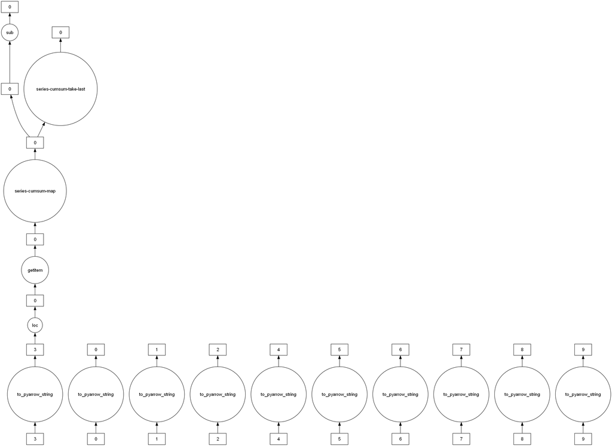

```python
result.visualize()
```

# Dask Array

다음은 Dask array를 활용해 위와 동일한 작업을 해보겠습니다. 먼저, NumPy 라이브러리를 사용해 Dask Array에 입력할 배열(array)을 생성해보겠습니다.

```python
data = np.arange(100_000).reshape(200, 500)
data
```

```
array([[    0,     1,     2, ...,   497,   498,   499],
       [  500,   501,   502, ...,   997,   998,   999],
       [ 1000,  1001,  1002, ...,  1497,  1498,  1499],
       ...,
       [98500, 98501, 98502, ..., 98997, 98998, 98999],
       [99000, 99001, 99002, ..., 99497, 99498, 99499],
       [99500, 99501, 99502, ..., 99997, 99998, 99999]])
```

```python
a = da.from_array(data, chunks=(100, 100))
a
```

|  | Array | Chunk |
| --- | --- | --- |
| Bytes | 390.62 kiB | 39.06 kiB |
| Shape | (200, 500) | (100, 100) |
| Dask graph | 10 chunks in 1 graph layer |  |
| Data type | int32 numpy.ndarray |  |

이제 (200, 500) 형태의 2D 배열(array)을 (100, 100) 형태의 10개 덩어리(chunk)로 나눈 Dask array 객체 `a`를 생성했습니다. 여기서 덩어리(chunk)는 데이터 조각을 나타냅니다. 다음은 Dask Array의 주요 속성입니다.

```python
# 덩어리(Chunk) 검사
a.chunks
```

```
((100, 100), (100, 100, 100, 100, 100))
```

```python
# 특정 데이터 덩어리(chunk)에 액세스
a.blocks[1, 3]
```

|  | Array | Chunk |
| --- | --- | --- |
| Bytes | 39.06 kiB | 39.06 kiB |
| Shape | (100, 100) | (100, 100) |
| Dask graph | 1 chunks in 2 graph layers |  |
| Data type | int32 numpy.ndarray |  |

```python
a[:50, 200]
```

|  | Array | Chunk |
| --- | --- | --- |
| Bytes | 200 B | 200 B |
| Shape | (50,) | (50,) |
| Dask graph | 1 chunks in 2 graph layers |  |
| Data type | int32 numpy.ndarray |  |

```python
a[:50, 200].compute()
```

```
array([  200,   700,  1200,  1700,  2200,  2700,  3200,  3700,  4200,
        4700,  5200,  5700,  6200,  6700,  7200,  7700,  8200,  8700,
        9200,  9700, 10200, 10700, 11200, 11700, 12200, 12700, 13200,
       13700, 14200, 14700, 15200, 15700, 16200, 16700, 17200, 17700,
       18200, 18700, 19200, 19700, 20200, 20700, 21200, 21700, 22200,
       22700, 23200, 23700, 24200, 24700])
```

```python
a.mean()
```

|  | Array | Chunk |
| --- | --- | --- |
| Bytes | 8 B | 8 B |
| Shape | () | () |
| Dask graph | 1 chunks in 5 graph layers |  |
| Data type | float64 numpy.ndarray |  |

```python
a.mean().compute()
```

```
49999.5
```

```python
np.sin(a)
```

|  | Array | Chunk |
| --- | --- | --- |
| Bytes | 781.25 kiB | 78.12 kiB |
| Shape | (200, 500) | (100, 100) |
| Dask graph | 10 chunks in 2 graph layers |  |
| Data type | float64 numpy.ndarray |  |

```python
np.sin(a).compute()
```

```
array([[ 0.        ,  0.84147098,  0.90929743, ...,  0.58781939,
         0.99834363,  0.49099533],
       [-0.46777181, -0.9964717 , -0.60902011, ..., -0.89796748,
        -0.85547315, -0.02646075],
       [ 0.82687954,  0.9199906 ,  0.16726654, ...,  0.99951642,
         0.51387502, -0.4442207 ],
       ...,
       [-0.99720859, -0.47596473,  0.48287891, ..., -0.76284376,
         0.13191447,  0.90539115],
       [ 0.84645538,  0.00929244, -0.83641393, ...,  0.37178568,
        -0.5802765 , -0.99883514],
       [-0.49906936,  0.45953849,  0.99564877, ...,  0.10563876,
         0.89383946,  0.86024828]])
```

```python
a.T
```

|  | Array | Chunk |
| --- | --- | --- |
| Bytes | 390.62 kiB | 39.06 kiB |
| Shape | (500, 200) | (100, 100) |
| Dask graph | 10 chunks in 2 graph layers |  |
| Data type | int32 numpy.ndarray |  |

```python
a.T.compute()
```

```
array([[    0,   500,  1000, ..., 98500, 99000, 99500],
       [    1,   501,  1001, ..., 98501, 99001, 99501],
       [    2,   502,  1002, ..., 98502, 99002, 99502],
       ...,
       [  497,   997,  1497, ..., 98997, 99497, 99997],
       [  498,   998,  1498, ..., 98998, 99498, 99998],
       [  499,   999,  1499, ..., 98999, 99499, 99999]])
```

NumPy 메서드처럼 Dask Array의 메서드도 연결하여 사용할 수 있습니다.

```python
b = a.max(axis=1)[::-1]+10
b
```

|  | Array | Chunk |
| --- | --- | --- |
| Bytes | 800 B | 400 B |
| Shape | (200,) | (100,) |
| Dask graph | 2 chunks in 6 graph layers |  |
| Data type | int32 numpy.ndarray |  |

```python
b[:10].compute()
```

```
array([100009,  99509,  99009,  98509,  98009,  97509,  97009,  96509,
        96009,  95509])
```

```python
b.dask
```

HighLevelGraph

HighLevelGraph with 6 layers and 30 keys from all layers.

**Layer1: array**

array-cc776c6b9a569dbadabcea53d1c7a075

| layer_type | MaterializedLayer |
| --- | --- |
| is_materialized | True |
| number of outputs | 10 |
| shape | (200, 500) |
| dtype | int32 |
| chunksize | (100, 100) |
| type | dask.array.core.Array |
| chunk_type | numpy.ndarray |

**Layer2: chunk_max**

chunk_max-3bc9e5bc8ce344a8a540ad6766f630e4

| layer_type | Blockwise |
| --- | --- |
| is_materialized | False |
| number of outputs | 10 |
| shape | (200, 500) |
| dtype | int32 |
| chunksize | (100, 100) |
| type | dask.array.core.Array |
| chunk_type | numpy.ndarray |
| depends on | array-cc776c6b9a569dbadabcea53d1c7a075 |

**Layer3: chunk_max-partial**

chunk_max-partial-f1f52f76bb5fa43515fce61754a0379b

| layer_type | MaterializedLayer |
| --- | --- |
| is_materialized | True |
| number of outputs | 4 |
| shape | (200, 2) |
| dtype | int32 |
| chunksize | (100, 1) |
| type | dask.array.core.Array |
| chunk_type | numpy.ndarray |
| depends on | chunk_max-3bc9e5bc8ce344a8a540ad6766f630e4 |

**Layer4: max-aggregate**

max-aggregate-8dda418caf3a76e16f714cadc3579a77

| layer_type | MaterializedLayer |
| --- | --- |
| is_materialized | True |
| number of outputs | 2 |
| shape | (200,) |
| dtype | int32 |
| chunksize | (100,) |
| type | dask.array.core.Array |
| chunk_type | numpy.ndarray |
| depends on | chunk_max-partial-f1f52f76bb5fa43515fce61754a0379b |

**Layer5: getitem**

getitem-54bbd49a5504c058ce998827f3f1e423

| layer_type | MaterializedLayer |
| --- | --- |
| is_materialized | True |
| number of outputs | 2 |
| shape | (200,) |
| dtype | int32 |
| chunksize | (100,) |
| type | dask.array.core.Array |
| chunk_type | numpy.ndarray |
| depends on | max-aggregate-8dda418caf3a76e16f714cadc3579a77 |

**Layer6: add**

add-5c9048a2c61ec5b51c83b9801ed5d438

| layer_type | Blockwise |
| --- | --- |
| is_materialized | False |
| number of outputs | 2 |
| shape | (200,) |
| dtype | int32 |
| chunksize | (100,) |
| type | dask.array.core.Array |
| chunk_type | numpy.ndarray |
| depends on | getitem-54bbd49a5504c058ce998827f3f1e423 |

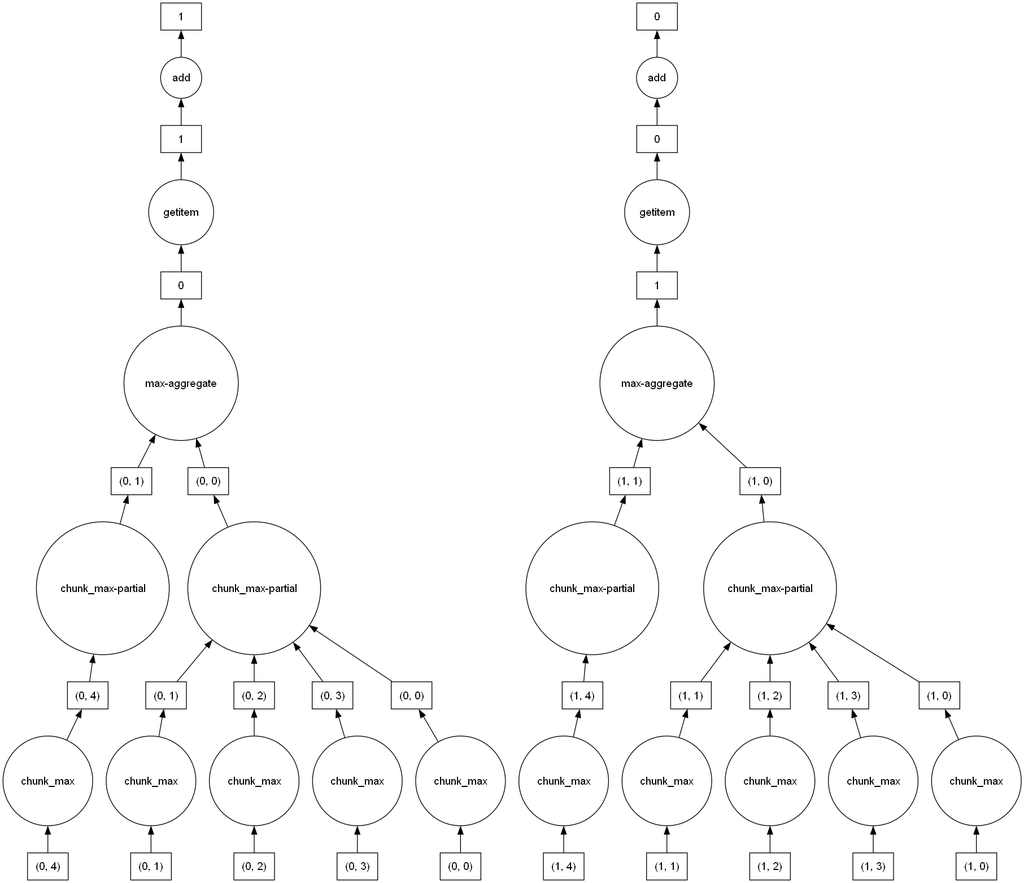

```python
b.visualize()
```

# Dask Bag

마지막으로 Dask Bag를 활용하여 마찬가지로 위와 동일한 작업을 진행해보겠습니다. 우선, Dask Bag 객체 `b`를 생성해줍니다.

```python
b = db.from_sequence([1, 2, 3, 4, 5, 6, 2, 1], npartitions=2)
b
```

```
dask.bag<from_sequence, npartitions=2>
```

8개 항목(items)으로 구성된 시퀀스(sequence)를 4개 항목으로 구성된 2개의 파티션(partitions)으로 나눠 Dask Bag 객체 `b`를 생성했습니다. 여기서 파티션은 데이터 조각을 나타냅니다.

다음은 인덱싱(indexing)을 할 차례지만, **Dask Bag**는 앞선 Dask DataFrame, Dask Array와 다르게 **인덱스(index)가 없는 데이터 구조**입니다. 이는 Dask Bag가 파이썬의 리스트(list)처럼 반복(iterate)은 가능하지만, Dask Bag의 경우 정렬(ordering)은 되지 않기 때문입니다. 따라서 요소(elements) 간의 순서를 보장하지 않습니다.

```python
b.compute()
```

```
[1, 2, 3, 4, 5, 6, 2, 1]
```

Dask Bag는 Python의 일반적인 컬렉션(예. 리스트) 객체처럼 `map`, `filter`, `fold`, `groupby`와 같은 작업들이 가능합니다.

```python
b.filter(lambda x: x % 2)
```

```
dask.bag<filter-lambda, npartitions=2>
```

```python
b.filter(lambda x: x % 2).compute()
```

```
[1, 3, 5, 1]
```

```python
b.distinct()
```

```
dask.bag<distinct-aggregate, npartitions=1>
```

```python
b.distinct().compute()
```

```
[1, 2, 3, 4, 5, 6]
```

마찬가지로 메서드들을 연결하여 함께 사용할 수 있습니다.

```python
c = db.zip(b, b.map(lambda x: x * 10))
c
```

```
dask.bag<zip, npartitions=2>
```

```python
c.compute()
```

```
[(1, 10), (2, 20), (3, 30), (4, 40), (5, 50), (6, 60), (2, 20), (1, 10)]
```

```python
c.dask
```

HighLevelGraph

HighLevelGraph with 3 layers and 6 keys from all layers.

**Layer1: from_sequence**

from_sequence-cca2a33ba6e12645a0c9bc0fd3fe6c88

| layer_type | MaterializedLayer |
| --- | --- |
| is_materialized | True |
| number of outputs | 2 |

**Layer2: lambda**

lambda-534eafdc975b2e8bbd0d2cae52c464bd

| layer_type | MaterializedLayer |
| --- | --- |
| is_materialized | True |
| number of outputs | 2 |
| depends on | from_sequence-cca2a33ba6e12645a0c9bc0fd3fe6c88 |

**Layer3: zip**

zip-ca4afde52fa305468e6fa67447c40b20

| layer_type | MaterializedLayer |
| --- | --- |
| is_materialized | True |
| number of outputs | 2 |
| depends on | lambda-534eafdc975b2e8bbd0d2cae52c464bd |
|  | from_sequence-cca2a33ba6e12645a0c9bc0fd3fe6c88 |

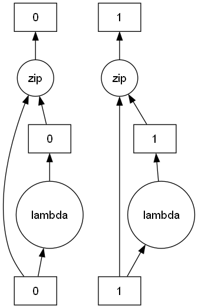

```python
c.visualize()
```

# Low-Level 인터페이스 : Dask Delayed

기존에 있는 코드를 병렬화하거나 사용자 지정 알고리즘을 구축할 때, 위와 같은 DataFrame, 배열(array) 유형을 사용하지 않는 코드를 병렬화 해야 할 경우도 있습니다. 이러한 경우, Dask Delayed를 이용할 수 있습니다.

[Dask Delayed](https://docs.dask.org/en/stable/delayed.html)를 사용하면 개별 함수 호출들을 작업 그래프로 생성할 수 있습니다.

```python
import dask

@dask.delayed
def inc(x):
   return x + 1

@dask.delayed
def add(x, y):
   return x + y

a = inc(1)       # 실제 연산이 실행되지 않음
b = inc(2)       # 실제 연산이 실행되지 않음
c = add(a, b)    # 실제 연산이 실행되지 않음

c = c.compute()  # compute를 호출해 위의 연산들을 실제로 실행
c
```

```
5
```

또는 함수가 실행되는 즉시 연산이 시작되길 원한다면, 아래와 같이 `dask.distributed.Client`를 사용하는 방법도 있습니다 ([Futures](https://docs.dask.org/en/stable/futures.html) 참조). 단, 이 방법은 분산 클러스터에서만 사용 가능합니다.

```python
from dask.distributed import Client

client = Client()

def inc(x):
   return x + 1

def add(x, y):
   return x + y

a = client.submit(inc, 1)     # 실제 연산이 바로 실행됨
b = client.submit(inc, 2)     # 실제 연산이 바로 실행됨
c = client.submit(add, a, b)  # 실제 연산이 바로 실행됨

c = c.result()                # 결과들을 수집해서 산출
c
```

```
5
```

# 스케줄링 Client

작업 그래프(Task graph)를 생성한 후, 이를 실행하는 것은 스케줄러의 역할입니다 ([스케줄링](https://docs.dask.org/en/stable/scheduling.html) 참조).

기본적으로, 대부분의 Dask API ([Dask Array](https://docs.dask.org/en/stable/array.html), [Dask DataFrame](https://docs.dask.org/en/stable/dataframe.html), [Dask Delayed](https://docs.dask.org/en/stable/delayed.html))의 경우 Dask 객체에서 `compute`를 호출하면, Dask는 컴퓨터의 스레드 풀(스레드 스케줄러)을 사용하여 병렬 연산을 실행합니다. 그 외, [Dask Bag](https://docs.dask.org/en/stable/bag.html)만 예외적으로 다중처리 스케줄러를 사용합니다.

더 많은 리소스를 활용해 제어하기를 원한다면 분산 스케줄러를 사용해야 합니다. 이 분산 스케줄러는 단일 머신과 다중 머신에서 모두 작동시킬 수 있습니다.

## 로컬 환경 (Local)

아래 코드는 로컬 컴퓨터만 사용해 클러스터를 설정하는 방법입니다.

```python
from dask.distributed import Client

client = Client()
client
```

Client

Client-0f60577c-3d7a-11ee-a6c4-002b6765fa53

| **Connection method:** Cluster object | **Cluster type:** distributed.LocalCluster |
| --- | --- |
| **Dashboard:** http://127.0.0.1:53421/status |  |

**Cluster Info**

LocalCluster

47bc4bec

| **Dashboard:** http://127.0.0.1:53421/status | **Workers:** 4 |
| --- | --- |
| **Total threads:** 8 | **Total memory:** 15.87 GiB |
| **Status:** running | **Using processes:** True |

**Scheduler Info**

Scheduler

Scheduler-6b34d5bb-d079-415f-89ec-58fcce3a46dd

| **Comm:** tcp://127.0.0.1:53424 | **Workers:** 4 |
| --- | --- |
| **Dashboard:** http://127.0.0.1:53421/status | **Total threads:** 8 |
| **Started:** Just now | **Total memory:** 15.87 GiB |

**Workers**

**Worker: 0**

| **Comm:** tcp://127.0.0.1:53456 | **Total threads:** 2 |
| --- | --- |
| **Dashboard:** http://127.0.0.1:53457/status | **Memory:** 3.97 GiB |
| **Nanny:** tcp://127.0.0.1:53427 |  |
| **Local directory:** C:\Users\BEGAS_15\AppData\Local\Temp\dask-scratch-space\worker-m414m7d1 |  |

**Worker: 1**

| **Comm:** tcp://127.0.0.1:53459 | **Total threads:** 2 |
| --- | --- |
| **Dashboard:** http://127.0.0.1:53460/status | **Memory:** 3.97 GiB |
| **Nanny:** tcp://127.0.0.1:53428 |  |
| **Local directory:** C:\Users\BEGAS_15\AppData\Local\Temp\dask-scratch-space\worker-zi8mm6cu |  |

**Worker: 2**

| **Comm:** tcp://127.0.0.1:53453 | **Total threads:** 2 |
| --- | --- |
| **Dashboard:** http://127.0.0.1:53454/status | **Memory:** 3.97 GiB |
| **Nanny:** tcp://127.0.0.1:53429 |  |
| **Local directory:** C:\Users\BEGAS_15\AppData\Local\Temp\dask-scratch-space\worker-b0kna_uz |  |

**Worker: 3**

| **Comm:** tcp://127.0.0.1:53450 | **Total threads:** 2 |
| --- | --- |
| **Dashboard:** http://127.0.0.1:53451/status | **Memory:** 3.97 GiB |
| **Nanny:** tcp://127.0.0.1:53430 |  |
| **Local directory:** C:\Users\BEGAS_15\AppData\Local\Temp\dask-scratch-space\worker-muklls29 |  |

## 원격 환경 (서버)

이번에는 이미 실행 중인 원격 클러스터에 연결하는 방법을 알아보겠습니다. 이외에도 원격 클러스터를 설정하는 방법에는 여러 가지가 있습니다. 자세한 내용은 [dask 클러스터 배포 방법(Deploy Dask Clusters)](https://docs.dask.org/en/stable/deploying.html)을 참조하시길 바랍니다.

```python
from dask.distributed import Client

client = Client("<url-of-scheduler>")  # 원격 서버 url 주소 입력
client
```

# 진단 Dashboard

분산 클러스터를 사용할 때, Dask는 작업이 처리되는 것을 볼 수 있는 대시보드(dashboard)를 제공합니다. `Client` 객체의 대시보드(Dashboard) 주소를 통해 리소스 및 작업 현황들을 실시간으로 확인할 수 있습니다. 자세히 알아보려면 [진단 대시보드(Dashboard Diagnostics)](https://docs.dask.org/en/stable/dashboard.html)를 참조하시길 바랍니다.

```python
client.dashboard_link
```

```
'http://127.0.0.1:53421/status'
```

[figure not shown]